# Age of Sexual Maturity

# 1 Preamble

This is an Electronic Supplement to the manuscript Schwacke et al. 2022. Modeling population effects of the Deepwater Horizon oil spill on a long-lived species. $Conservation~Biology$ 36:e13878 DOI: https://doi.org/10.1111/cobi.13878

The master file containing links to all supplementary files related to this paper is BND_Electronic Supplements master file.

If you make use of any of this material in your work, it would be appreciated if you would contact Tiago Marques to let him know.

In case you are reading this document on git while browsing the material for the pelagic paper, the master file with supplementary material for the pelagic paper is here: Electronic Supplements master file.

# 2 Introduction

Here we describe the meta-analysis undertaken to determine age at sexual maturity in wild bottlenose dolphins. We found two relevant datasets: one from a study based on necropsies of stranded animals from the central Atlantic Coast of the US between 1975 and 1987 (Mead and Potter 1990), and the other from observations of known-age animals with first calves from a well-studied population in Sarasota Bay (Wells et al in prep).

The target parameter here is age at sexual maturity (ASM), i.e., the age at which a female is physiologically capable of becoming pregnant. In the population model, females from this age onwards can give birth the following year. The data from the Mead and Potter study presumably (it is not stated explicitly) measure whether ovulation has taken place, and hence give direct measurements of whether a female of the observed age is sexually mature or not. The data from the Sarasota Bay study are of whether a female was observed with a calf or not. Since gestation is approximately one year, a female with a calf must have been sexually mature at least one year earlier, so we subtract 1 from the ages. Given that this is a well-monitored population we assume that the time between birth and the calf being observed is negligible. Lastly, we assume that the time between attainment of sexual maturity and first pregnancy is negligible. Given these assumptions, the mean ASM is estimated by mean age when first observed with a calf minus 1.

We first undertake a binary regression on each dataset, regressing whether sexually mature or not (response variable) as a function of age (explanatory variable). These analyses yield estimates of the age at which 50% of the population are sexually mature. We then undertake a meta-analysis to combine these two estimates (using a variance-weighted mean).

# 3 Mead and Potter data

```r
mp.data <- data.frame(age = c(27,17,24,15,14,2,1,0,22,2,12,4,1.5,3,2,14,0,0,0,2,1,3,0,18,12,16,25,3,2,2,11,20,20,1,8,20,10,2.5,2,3,11,0,2.2,3,3,15,1,3,10,8,16), mature = c(1,1,1,1,1,0,0,0,1,0,1,0,0,0,0,1,0,0,0,0,0,0,0,1,1,1,1,0,0,0,1,1,1,0,1,1,1,1,0,0,1,0,0,0,0,0,0,0,1,0,1))
```

fit the GAM binomial model

```r
#Fit binary GAM
mod1 <- gam(mature ~ s(age), family = binomial, data = mp.data)
newdata <- data.frame(age = seq(min(mp.data$age), max(mp.data$age), length = 1000))
```

and then predict from it over the range of available ages

```r
#predict on the scale of the link function
pred <- predict(mod1, newdata = newdata, se.fit = TRUE)
#predict on the scale of the response - a probability
pred.r <- predict(mod1, newdata = newdata, se.fit = TRUE,type="response")
# which.max returns the index of first element to be equal to the maximum
# in a vector of true or false, that is the first true == 1
which.age.p.50 <- which.max(pred.r$fit > 0.5)
mp.age.p.50 <- newdata$age[which.age.p.50]
```

The predictions from the model are represented in the following plot:

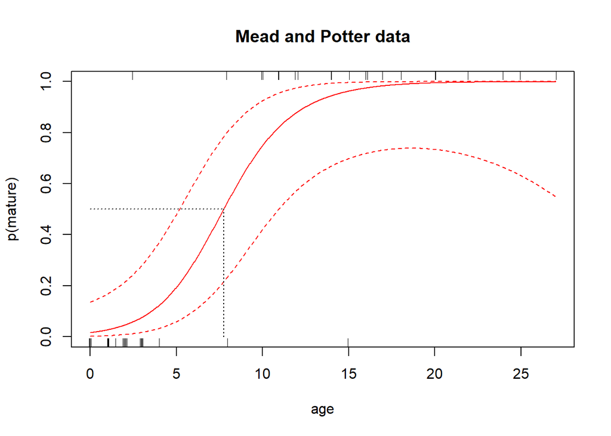

```r
#Plot predictions
plot(newdata$age, plogis(pred$fit), type = "l", col = "red", main = "Mead and Potter data", ylim = c(0, 1), ylab = "p(mature)", xlab = "age")
lines(newdata$age, plogis(pred$fit + 1.96 * pred$se.fit), lty = 2, col = "red")
lines(newdata$age, plogis(pred$fit - 1.96 * pred$se.fit), lty = 2, col = "red")
#show p.50
lines(c(mp.age.p.50, mp.age.p.50), c(0, 0.5), lty = 3)
lines(c(0, mp.age.p.50), c(0.5, 0.5), lty = 3)
#show data - jittered a little
rug(jitter(mp.data$age[mp.data$mature == 1], amount = 0.1), side = 3)
rug(jitter(mp.data$age[mp.data$mature == 0], amount = 0.1), side = 1)
```

We therefore estimate the age at which 50% of the animals are mature is 7.76.

Note two inconsistent observations which could correspond to recording errors - one immature animal aged 15 and one mature animal aged 2.5. While these may be incorrect, we have no evidence of this, so we retain them in the analysis.

We use a parametric bootstrap approach to obtain a standard error on the estimate of number of years at which probability of sexual maturity is 0.5.

```r
#Code adapted from predict.gam help
rmvn <- function(n,mu,sig) { ## MVN random deviates
  L <- mroot(sig);m <- ncol(L);
  t(mu + L%*%matrix(rnorm(m*n),m,n))
}
# Note required large number of replicates to reduce the Monte Carlo error
# on the estimated standard error
B <- 100000
Xp <- predict(mod1, newdata, type = "lpmatrix")
br <- rmvn(B, coef(mod1), mod1$Vp)
res <- rep(0, B)
for(i in 1:B){
  pred <- Xp %*% br[i, ]
  res[i] <- newdata$age[which.max(pred > 0)]
}
mp.se.age.p.50 <- sd(res)
#mp.se.age.p.50
#quantile(res, c(0.025, 0.975))
```

Therefore the predicted age of sexual maturity is 7.76 with SD 1.51 and 95% confidence interval 5.19-10.89.

# 4 Wells et al data

We read in the data

```r
sarasota <- read_excel("InOutBySp/Bottlenose_dolphin_BB/Sarasota Age at First Birth 11Mar20.xlsx",range = "A3:A55", col_names = FALSE)
names(sarasota) <- "age"
```

Below is an histogram of the ages at which females were first observed with a calf in the Sarasota Bay data.

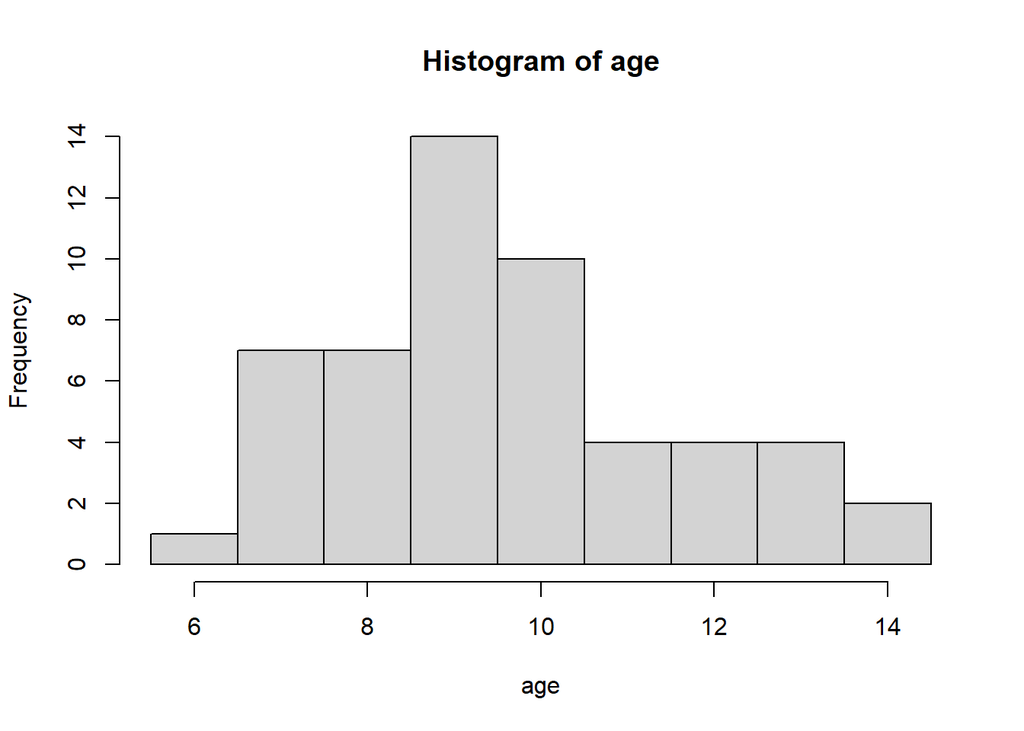

```r
with(sarasota, hist(age, breaks = seq(min(age) - 0.5, max(age) + 0.5, by = 1)))
```

```r
sa.mean <- mean(sarasota$age)
sa.sd <- sd(sarasota$age)
sa.se <- sa.sd/sqrt(length(sarasota$age))
```

From these 53 observations, the mean age when first seen with a calf is 9.6 with SD 1.96 and SE 0.2698.

As described previously, we wish to subtract 1from these values, to give age at sexual maturity. We take as IBI the inverse of the nominal fecundity from Schwacke et al. (2017).

```r
#Subtract 1 from the data to make it
# equal to mean age at sexual maturity
sa.mean <- sa.mean - 1
#sa.mean
```

This gives mean age of sexual maturity of 8.604 with standard error unchanged at 0.2698.

# 5 Meta-analysis

In combining these two estimates together, we used an inverse variance weighted mean.

```r
#Mead and Potter data
mp.mean <- mp.age.p.50
mp.se <- mp.se.age.p.50

#Inverse variance weighted average
asm.dat.mean <- c(sa.mean, mp.mean)
asm.dat.se <- c(sa.se, mp.se)
weights <- 1 / (asm.dat.se ^ 2)
asm.mean <- sum(weights * asm.dat.mean) / sum(weights)
asm.se <- sqrt (sum(weights ^ 2 * asm.dat.se ^ 2) / sum(weights ^ 2))
```

The Mead and Potter estimate has much higher standard error, and so hardly influences the composite estimate. Combined mean 8.578 and combined SE 0.274 (recall that the Mead and Potter estimate was 7.757 and the Wells et al. was 8.604).

This is illustrated in the plot below, which fits the mean and variance of each data source, and the composite, to gamma distributions.

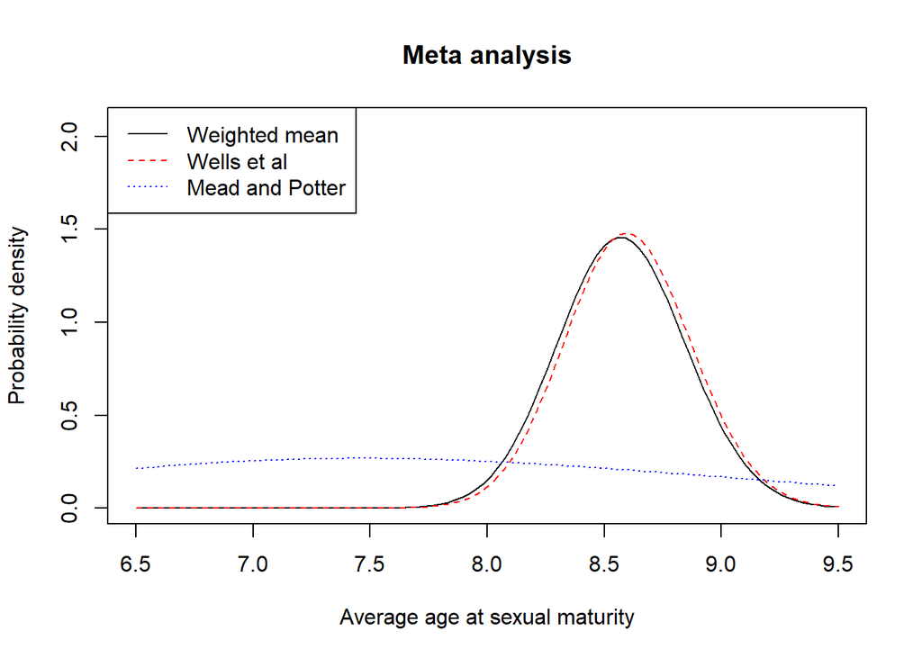

```r
get.gamma.par <- function(mean, var){
#Returns shape and scale parameter of gamma given mean and var
  return(list(shape = mean ^ 2 / var, scale = var / mean))
}

#Plot results
x <- seq(6.5, 9.5, length = 100)
asm.par <- get.gamma.par(asm.mean, asm.se ^ 2)
asm.res <- dgamma(x, shape = asm.par$shape, scale = asm.par$scale)
sa.par <- get.gamma.par(sa.mean, sa.se ^ 2)
sa.res <- dgamma(x, shape = sa.par$shape, scale = sa.par$scale)
mp.par <- get.gamma.par(mp.mean, mp.se ^ 2)
mp.res <- dgamma(x, shape = mp.par$shape, scale = mp.par$scale)
ylim <- c(0, max(asm.res, sa.res, mp.res) * 1.4)
plot(x, asm.res, xlab = "Average age at sexual maturity", ylab = "Probability density", main = "Meta analysis", type = "l", ylim = ylim)
lines(x, sa.res, lty = 2, col = "red")
lines(x, mp.res, lty = 3, col = "blue")
legend("topleft", legend = c("Weighted mean", "Wells et al", "Mead and Potter"), lty = 1:3, col = c("black", "red", "blue"))
```

The population dynamics model requires a discrete value for ASM. Hence we sampled from a gamma with mean and variance equal to the composite distribution, and rounded ot the nearest integer. The relevant gamma parameters are shape 980.1954275 and scale 0.0087509.

# 6 References

Mead, J.G. and C.W. Potter. 1990. A natural history of bottlenose dolphins along the central Atlantic coast of the United States. In *The Bottlenose Dolphin*, Eds S. Letherwood and R.R. Reeves. Academic Press.

Wells, R. S., M. D. Scott, A. A. Hohn, J. C. Sweeney, F. I. Townsend, J. B. Allen, A. A. Barleycorn, S. Hofmann, K. A. McHugh, C. R. Smith, R. C. Lacy, and A. B. Irvine. In preparation. Life history, reproductive biology and demographic parameters for common bottlenose dolphins, (*Tursiops truncatus*), in Sarasota Bay, Florida. *Frontiers in Marine Science, Marine Conservation and Sustainability*.

Schwacke, L.H., L. Thomas, R.S. Wells, W.E. McFee, A.A. Hahn, K.D. Mullin, E.S. Zolman, B.M. Quigley, T.K. Rowles and J.H. Schwacke. 2017. An age-, sex- and class-structured population model for estimating nearshore common bottlenose dolphin injury following the Deepwater Horizon oil spill. *Endangered Species Research* **33**: 265-279. DOI: 10.3354/esr00777.